# Stream and Floods

Dr. Ahmad Redaa

2025-04-26

# Outlines

- The Hydrological Cycle
- Drainage Basins
- Stream Erosion and Deposition
- Stream Types
- Flooding

# The Hydrological Cycle

The hydrological cycle (also called the water cycle) describes the continuous movement of water through the Earth’s systems—ocean, land, atmosphere, and biosphere. This process is essential to life on Earth and plays a central role in shaping geological features, particularly streams and rivers.

> Watch this [YouTube Video](https://www.youtube.com/watch?v=Sv16XOnNKeU) shows The Journey of a River

# The Water Cycle

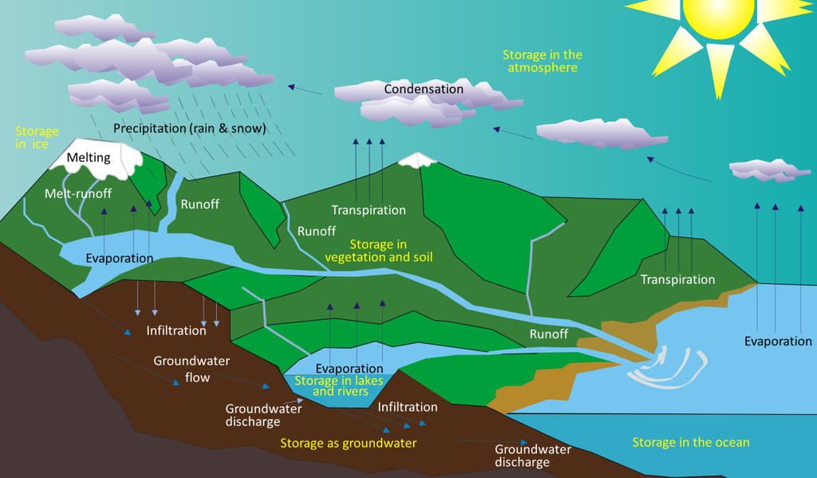

The various components of the water cycle. Black or white text indicates the movement or transfer of water from one reservoir to another. Yellow text indicates the storage of water. Source: [Steven, E. (2015)](https://openlibrary-repo.ecampusontario.ca/jspui/handle/123456789/402)

- Water is constantly cycling, even if most of it remains in the ocean.
- Streams are a small but critical component of this cycle.
- Even tiny percentages (like 0.03% in rivers/lakes) play a **vital role** in shaping Earth’s surface and supporting life.
- Understanding residence time helps us model climate, predict droughts, and manage water resources.

# Processes in the Water Cycle

The movement of water between reservoirs is driven by **solar energy** and **gravity** through the following processes:

| **Process** | **Description** |
| --- | --- |
| **Evaporation** | Water changes from liquid to gas, mostly from oceans and lakes. |
| **Transpiration** | Water is released from plant leaves into the atmosphere. |
| **Precipitation** | Water vapor condenses and falls as rain or snow. |
| **Infiltration** | Water seeps into the ground to become part of the groundwater system. |
| **Runoff** | Water moves over the land surface into streams and rivers. |
| **Groundwater flow** | Water slowly moves through subsurface materials back into streams or oceans. |

# Main Water Reservoirs

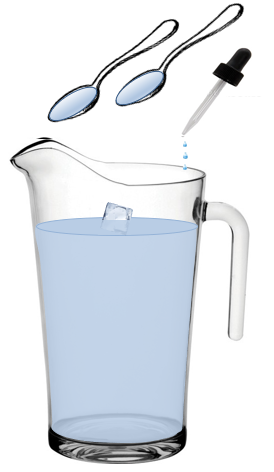

Representation of the Earth’s water. The 1 litre jug is filled with salty sea water (97%). The ice-cube is glacial ice (2%). The 2 teaspoons represent groundwater (1%), and the three drops represent all of the fresh water in lakes, streams, and wetlands, plus all of the water in the atmosphere. Source: [Steven, E. (2015)](https://openlibrary-repo.ecampusontario.ca/jspui/handle/123456789/402)

- Water exists in several key storage systems or **reservoirs** on Earth:

| **Reservoir** | **Proportion of Earth’s Water** |
| --- | --- |
| Oceans (saltwater) | ~97% |
| Glaciers and ice caps | ~2% |
| Groundwater | ~1% |
| Lakes, rivers, atmosphere | ~0.03% |

> **Note:** Even though lakes and rivers hold only a tiny fraction of Earth’s water, they are crucial for ecosystems and human use.
- Imagine Earth’s water in a **1 litre jug**:
  - 970 ml = salty ocean water (+34 g salt)
  - 1 ice cube (~20 ml) = glacial ice
  - 2 teaspoons (~10 ml) = groundwater
  - 3 drops = lakes, streams, atmosphere

# Water in the Atmosphere

- Despite the tiny proportion, **atmospheric water** volume = ~13,000 km³.
- **Evaporation**: ~1,580 km³/day from oceans, lakes, vegetation.
- **Precipitation** matches evaporation daily over oceans and land.

# Streamflow and Return to Oceans

- Precipitation on land returns via:
  - **Streamflow**: 117 km³/day
  - **Groundwater flow**: 6 km³/day
- Example: **Fraser River discharge** ≈ 0.31 km³/day (0.26% of all rivers’ flow).

# Residence Time of Water

**Residence time** refers to the **average amount of time** water spends in a given reservoir.

[output not shown]

# Drainage Basins

A **drainage basin** (also called a watershed) is the land area from which all precipitation collects and flows into a particular stream or river. It includes all surface water from rain, snowmelt, and nearby streams that drain into the main stream channel. A **stream** is any body of flowing water, regardless of size.

# Definitions - Drainage Basins

- **Stream:** A channel of flowing water, from small creeks to large rivers.
- **Drainage Basin:** The area of land where precipitation collects and drains into a stream.
- **Drainage Divide:** The boundary between two drainage basins, typically marked by a ridge or high point of land.

# Types of Drainage Patterns

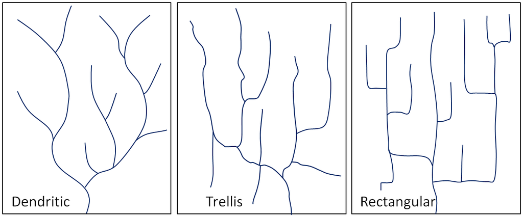

Typical dendritic, trellis, and rectangular stream drainage patterns. Source: [Steven, E. (2015)](https://openlibrary-repo.ecampusontario.ca/jspui/handle/123456789/402)

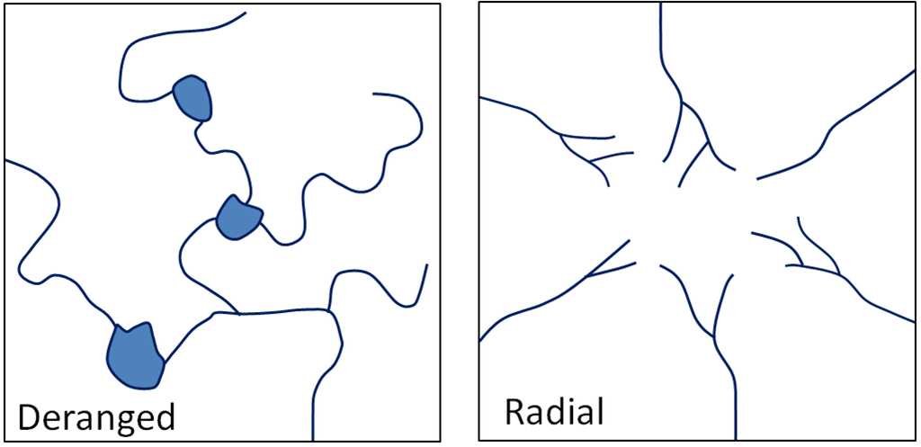

Left: a typical deranged pattern; right: a typical radial drainage pattern developed around a mountain or hill. Source: [Steven, E. (2015)](https://openlibrary-repo.ecampusontario.ca/jspui/handle/123456789/402)

The shape and structure of drainage networks vary depending on geology and topography.

| **Pattern** | **Description** | **Common Settings** |
| --- | --- | --- |
| **Dendritic** | Tree-like branching; forms when rock is uniform and erodes equally in all directions | Granite, gneiss, volcanic rocks |
| **Trellis** | Parallel tributaries join at right angles; influenced by folded or tilted layers | Folded sedimentary rocks, e.g., Rockies |
| **Rectangular** | Streams follow jointed or faulted rock, forming right angles | Fractured bedrock or fault zones |
| **Deranged** | Irregular, chaotic patterns with many lakes and wetlands | Glaciated terrain, Canadian Shield |
| **Radial** | Streams radiate outward from a central high point | Volcanic cones or domes |

# Graded vs. Ungraded Streams

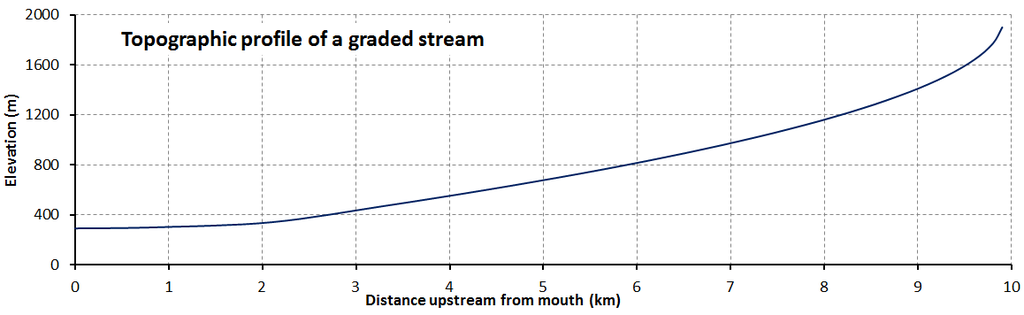

The topographic profile of a typical graded stream. Source: [Steven, E. (2015)](https://openlibrary-repo.ecampusontario.ca/jspui/handle/123456789/402)

- **Graded Stream:** A stream in dynamic equilibrium, with a smooth concave profile where erosion = deposition.
- **Ungraded Stream:** Has irregular profile with steep drops, rapids, or waterfalls. Can become graded over time via erosion.

# Base Level and Stream Terraces

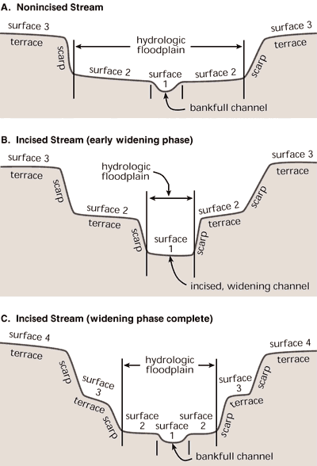

Terrace formation by incising or widening floodplains. Source: [https://cfpub.epa.gov](https://cfpub.epa.gov/watertrain/moduleFrame.cfm?parent_object_id=641&object_id=645)

## **Base Level**

- The lowest point a stream can erode to:
  - **Ultimate base level** = Sea level
  - **Temporary base level** = Lakes, larger rivers, or dams

## **Stream Terraces**

- Formed when a stream cuts down into its own floodplain.
- Usually created due to:
  - A drop in base level
  - Decrease in sediment supply
  - Uplift of land

> Watch this [YouTube video](https://www.youtube.com/watch?v=o-CMjc2t5Sc) to learn how streams (i.e., rivers) develop.

# Natural and Artificial Base Level Changes

| **Cause** | **Effect on Stream** |
| --- | --- |
| **Natural uplift** | Increases gradient → more erosion → rejuvenation of stream |
| **Sea level drop** | Lowers base level → stream incises deeper into valley |
| **Glacial rebound** | Raises land, creating new waterfalls or canyons |
| **Dam construction** | Creates an artificial lake (reservoir) → raises local base level |

> Watch this [YouTube video](https://www.youtube.com/watch?v=V7HP1jsoisE) to learn about Glacial Rebound

# The Davis Cycle of Erosion

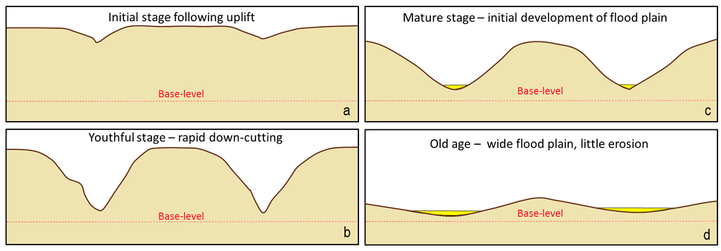

A depiction of the Davis cycle of erosion: a: initial stage, b: youthful stage, c: mature stage, and d: old age. Source: [Steven, E. (2015)](https://openlibrary-repo.ecampusontario.ca/jspui/handle/123456789/402)

- Proposed by geologist **William Davis**, this model describes how landscapes evolve over time through stream erosion.

| **Stage** | **Description** |
| --- | --- |
| **Youthful** | Steep gradients, V-shaped valleys, waterfalls and rapids, active downcutting |
| **Mature** | Wider valleys, reduced gradients, more lateral erosion, sediment deposition |
| **Old Age** | Broad floodplains, meanders, low energy, extensive deposition |

> ️ **Note:** While the Davis model is simplified and predates plate tectonics, it remains useful for conceptualising stream evolution.
- Streams shape landscapes over time through erosion and deposition.
- Drainage patterns reflect underlying rock and tectonic history.
- Streams evolve from steep, fast-flowing channels to low-gradient, meandering rivers.
- Understanding stream behavior is essential for flood management, land planning, and environmental protection.

# Stream Erosion and Deposition

Streams are powerful agents of **erosion**, **transportation**, and **deposition**. The movement of sediment and solutes in a stream is controlled by **velocity**, **channel shape**, and **discharge volume**. Understanding how sediment moves helps explain stream dynamics, floodplain development, and landscape evolution.

# Velocity Distribution in Stream Channels

> Stream velocity is not uniform:
- **Fastest Flow:** Just below the surface, near the center of the channel.
- **Slowest Flow:** Along the bottom and edges due to friction.
- **In Curves (Meanders):**
  - Fastest on the **outside bend** → erosion.
  - Slowest on the **inside bend** → deposition.

| **Stream Condition** | **Effect on Velocity** |
| --- | --- |
| Smooth channel, high gradient | High velocity |
| Rough bed or wide shallow channel | Lower velocity due to friction |
| During flood (bank-full stage) | Velocity increases significantly |

# Sediment Transport Types

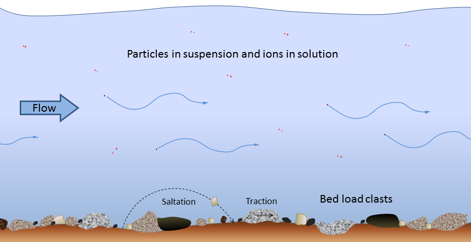

Modes of transportation of sediments and dissolved ions (represented by red dots with + and − signs) in a stream. Source: [Steven, E. (2015)](https://openlibrary-repo.ecampusontario.ca/jspui/handle/123456789/402)

- Stream sediments are transported in three main ways:

| **Transport Type** | **Description** |
| --- | --- |
| **Bed Load** | Large particles (sand, gravel, cobbles) that roll, slide, or bounce (saltation) along the bed. |
| **Suspended Load** | Finer particles (silt, clay) carried in suspension; influenced by turbulence. |
| **Dissolved Load** | Soluble ions (e.g., Ca²⁺, Cl⁻) transported invisibly in water. |

> The **volume of each load** type varies with stream velocity and sediment availability.

# Hjulström-Sundborg Diagram

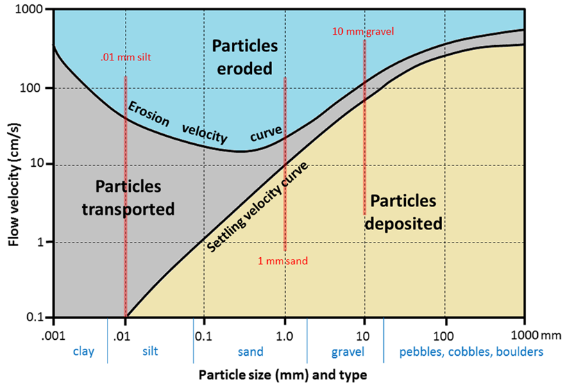

The Hjulström-Sundborg diagram showing the relationships between particle size and the tendency to be eroded, transported, or deposited at different current velocities. Source: [Steven, E. (2015)](https://openlibrary-repo.ecampusontario.ca/jspui/handle/123456789/402)

- This table illustrates the relationship between **stream velocity** and **particle size**, showing when particles are **eroded**, **transported**, or **deposited**.

[output not shown]

> Erosion requires **higher velocity** than transport or deposition.

- When streams flood:
  1. Water spills over the banks and spreads across the **floodplain**.
  2. **Velocity drops suddenly** due to increased channel width.
  3. **Coarse sediment** (sand, silt) is deposited along the edge of the channel.
  4. **Finer particles** (clay) travel farther before settling.

# Formation of Natural Levées

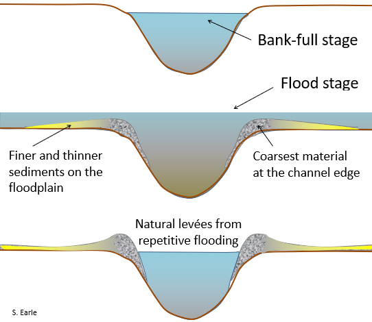

The development of natural levées during flooding of a stream. The sediments of the levée become increasingly fine away from the stream channel, and even finer sediments—clay, silt, and fine sand—are deposited across most of the flood plain. Source: [Steven, E. (2015)](https://openlibrary-repo.ecampusontario.ca/jspui/handle/123456789/402)

| **Process** | **Result** |
| --- | --- |
| Flood overtops banks | Sediment drops quickly |
| Repeated flooding | Builds up raised banks = **levées** |
| Beyond levées | Floodplain with finer sediments |

> These natural embankments can help contain future floods—until overtopped.

# Stream Types

Stream channels vary in shape, energy, and sediment transport depending on their gradient, geology, sediment supply, and stage of landscape evolution. Understanding different stream types helps us interpret river systems and their associated landforms.

# Characteristics of Stream Types

| **Stream Type** | **Key Characteristics** |
| --- | --- |
| **Youthful Streams** | - Steep gradients - Narrow, V-shaped valleys - High erosion rates - Features like rapids, waterfalls, step-pool morphology |
| **Braided Streams** | - Multiple shallow channels separated by bars - High sediment load - Often found in glacial valleys or volcanic regions |
| **Meandering Streams** | - Single, sinuous channel - Low gradient, broad floodplain - Erosion on outer bends and deposition on inner bends |

# Step-Pool Morphology and Sediment Dynamics

## **Step-Pool Morphology**

- Common in **youthful, steep streams**.
- Stream alternates between:
  - **Pools:** Deep, slow-moving water sections.
  - **Steps:** Short, turbulent drops, often over large boulders or bedrock.

## Function:

- Step-pool structures dissipate stream energy, reducing erosion and promoting sediment sorting.

# Sediment Dynamics

| **Sediment Process** | **Description** |
| --- | --- |
| **Bed Load Transport** | Large particles (gravel, cobbles) bounce or roll along the stream bed (traction, saltation). |
| **Suspended Load** | Fine sediments (silt, clay) carried within the water column. |
| **Channel Changes** | During high flow (floods), streams erode banks, deposit sediments, and shift positions. |

- In **braided streams**, sediment supply exceeds transport capacity, causing frequent channel shifts.
- In **meandering streams**, erosion dominates on the **outer bend** (cut bank) and deposition on the **inner bend** (point bar).

# Deltas and Their Formation at River Mouths

## **Delta Formation**

- A **delta** forms where a stream enters a standing body of water (lake, sea) and **deposits sediment**.
- Stream velocity drops suddenly → **sediments settle out**.

| **Delta Characteristics** | **Description** |
| --- | --- |
| **Coarse material** deposits near river mouth | Sand, gravel form topset beds. |
| **Fine material** carried farther | Silt, clay form foreset and bottomset beds. |
| **Delta Progradation** | Deltas build outward into the water body over time. |

# Flooding

- Flooding occurs when a stream’s discharge exceeds the capacity of its channel, causing water to spill onto the surrounding floodplain. Floods shape landscapes, enrich soils, but also threaten human settlements.
- Understanding the seasonal patterns of stream discharge and historic flood events helps in planning and mitigation strategies.

# Seasonal Stream Discharge Patterns

| **Region** | **Discharge Pattern** |
| --- | --- |
| **Continental Canada** | Highest discharge in **late spring and early summer** due to snowmelt. |
| **Coastal British Columbia** | Highest discharge in **winter** from rainfall; lower seasonal snow influence. |

# Flood Prevention Strategies

| **Strategy** | **Purpose** |
| --- | --- |
| **Floodplain Zoning** | Restricts building in flood-prone areas to minimize risk. |
| **Dyking** | Builds levees or embankments to contain floodwaters. |
| **Monitoring** | Tracks snowpack, precipitation, and stream discharge. |
| **Emergency Planning** | Prepares evacuation routes, warnings, and response plans. |
| **Public Education** | Informs citizens about risks and safe actions during floods. |